# Introduction to Ordination

### Let’s start working

The data we’ll be using today come from a dataset called NeoTropTree which was developed by [Professor Ary Oliveira-Filho (Federal University of Minas Gerais - Brazil)](http://prof.icb.ufmg.br/treeatlan/). NeoTropTree is a large database containing records on forest tree species composition, gathered by reviewing the literature (published and unpublished - e.g. masters dissertations and PhD theses), compiling species check-lists, and studying herbarium records. Each site within the database has been assigned to a specific vegetation type (an ecologically meaningful unit). NeoTropTree is a very comprehensive and well kept dataset, which makes it very valuable and reliable when doing science. Professor Oliveira-Filho has kindly agreed to us using a tiny portion of it for this tutorial.

```r
# Load the dataset for which NoTropTree has at least one record in Bolivia.
spp <- vroom::vroom('spp_bol.csv')
spp
```

```
## # A tibble: 3,369 × 5
##       SppID Family          Genus         Species                   Species.code
##       <dbl> <chr>           <chr>         <chr>                     <chr>
##  1 42552216 ACANTHACEAE     Aphelandra    Aphelandra castaneifolia  Aphecast
##  2 42552104 ACANTHACEAE     Suessenguthia Suessenguthia multisetosa Suesmult
##  3 42552105 ACANTHACEAE     Suessenguthia Suessenguthia wenzelii    Sueswenz
##  4    50009 ACHARIACEAE     Carpotroche   Carpotroche longifolia    Carplong
##  5    50014 ACHARIACEAE     Lindackeria   Lindackeria paludosa      Lindpalu
##  6    50018 ACHARIACEAE     Mayna         Mayna odorata             Maynodor
##  7 42551050 ACHATOCARPACEAE Achatocarpus  Achatocarpus microcarpus  Achamicr
##  8    50020 ACHATOCARPACEAE Achatocarpus  Achatocarpus nigricans    Achanigr
##  9    50021 ACHATOCARPACEAE Achatocarpus  Achatocarpus praecox      Achaprae
## 10    50022 ACTINIDIACEAE   Saurauia      Saurauia chaparensis      Saurchap
## # ℹ 3,359 more rows
```

Each species has a SppID number and a code, which is in the Species.code column. These two columns will be of major importance to us later on. There are 3369 tree species registered for Bolivia in NeoTropTree.

```r
# Load the dataframe containing all sites NeoTropTree has in Bolivia.
sites <- vroom::vroom('sites_bolivia.csv', delim = ',')
sites
```

```
## # A tibble: 217 × 22
##    AreaID AreaCode Locality    Country `State/Province` Latitude Longitude Lat10
##     <dbl> <chr>    <chr>       <chr>   <chr>            <chr>    <chr>     <dbl>
##  1   2566 AmzBO001 "Santa Ros… Bolivia Pando            "10\xb0… "67\xb02… -10.6
##  2   2629 AmzBO002 "Aeropista… Bolivia Pando            "10\xb0… "66\xb04… -10.8
##  3   2630 AmzBO003 "Puerto Ri… Bolivia Pando            "10\xb0… "67\xb04… -11.0
##  4   5418 AmzBO004 "Cobija y … Bolivi… Pando/Acre       "11\xb0… "68\xb04… -11.1
##  5   2568 AmzBO005 "Conquista… Bolivia Pando            "11\xb0… "67\xb02… -11.3
##  6   2569 AmzBO006 "Chivesito… Bolivia Pando            "11\xb0… "68\xb04… -11.6
##  7   2570 AmzBO007 "Reserva M… Bolivia Pando            "11\xb0… "68\xb01… -11.7
##  8   2626 AmzBO008 "Blanca Fl… Bolivia Pando            "11\xb0… "67\xb01… -11.7
##  9   2638 AmzBO009 "Pacaguara… Bolivia La Paz           "12\xb0… "67\xb05… -13.0
## 10   5425 AmzBO010 "Estacion … Bolivia Beni             "14\xb0… "66\xb01… -14.7
## # ℹ 207 more rows
## # ℹ 14 more variables: Long10 <dbl>, Altitude <dbl>, `Alt SRTM` <dbl>,
## #   Domain <chr>, EcoUnit <chr>, FitGeoN <dbl>, `Asp Ocean` <chr>,
## #   `Thermic realm` <chr>, `Elevation range` <chr>, `Zonal Azonal` <chr>,
## #   `Climatic regime` <chr>, `Leaf flush` <chr>,
## #   `Vegetation physiognomy` <chr>, `Vegetation type` <chr>
```

Each site has an AreaID, an Area Code, information on locality, vegetation type, geographic coordinates and elevation. You can also see that the sites are classified in Phytogeographic Domains (Domain). This is important because the AreaCode column, to which we’ll be referring very often, is based on these domains - the first three letters of an area code correspond to the Domain on which the site is located. Sites beginning with Amz, are a part of the Amazon Domain; And = Andes; Cer = Cerrado (South American savannas); Cha = Chaco woodlands (mainly subtropical, shrubby, mostly deciduous and dry floristic formation). Pay attention to this, as this will be very important when looking for sub-groups in our dataset.

Now it’s time for us to load the correspondence matrix, a matrix indicating what species are present on which site, information that is vital to us in order to make a presence and abscence matrix.

```r
# Load the sppxarea matrix
sppxsites <- vroom::vroom('sppxsites_bol.csv', del = ',')
sppxsites
```

```
## # A tibble: 42,015 × 2
##    AreaID    SppID
##     <dbl>    <dbl>
##  1   3768 42548321
##  2   3768 42547343
##  3   3768 42552077
##  4   3768    54508
##  5   3768 42548053
##  6   3768    52320
##  7   3768    51045
##  8   3768    52056
##  9   3768 42547194
## 10   3768 42549484
## # ℹ 42,005 more rows
```

Please note that you only have two columns in here - SppID and AreaID.The number of rows is the number of occurrence records in our dataset - 42015.

### Making a presence/absence matrix through a loop

How does the chosen clustering method know which observations are more similar to one another than others? Simple. You will provide it with a pairwise distance matrix. This is a quadratic (number of rows is equal to the number of columns) matrix containing the distance values taken for each pair of sites in the dataset. There are different ways of calculating these pairwise distances and the most suitable method for you will largely depend on the kind of data you are working with.

Right now, what we need to do is use the data frames we have and create a presence and absence matrix with sites in the rows and species in the columns. As it is standard, 1 = species present in a site and 0 = the species absent in a site. No matter what distance metric you use, the pairwise distance matrix that will be used when clustering your data will always be constructed based on this table. Of course, if you have species abundance, than you’ll be working with an abundance matrix.

The way we are going to build such matrix is through a loop function. Loop functions are extremely useful used in many programming languages. If you want to learn more about them, you can check our tutorial on how to use loops.

```r
# Making the species by site matrix (presence and abscence). We'll call it `commat`.
sites_sub <- unique(sppxsites$AreaID)   # Making a vector with sites in our dataset
spp_sub <- unique(sppxsites$SppID)   # Making a vector with species in our dataset

# First we'll create an empty matrix with our sites in the rows and our species in the columns. The loop function will place a `1` on a given cell when the species is present in an area and will fill out the remaining cells with a `0`.
# This is the loop given in the tutorial. A bit overly complex.
spp_commat <- matrix(data = 0, nrow = length(sites_sub), ncol = length(spp_sub))
for (i in 1:nrow(spp_commat)){
  temp_sites <- sppxsites[which(sppxsites$AreaID == sites_sub[i]),]
  spp_commat[i, which(spp_sub %in% temp_sites$SppID)] <- 1
}

# Now let's name our rows and columns with the codes for the sites and the codes for the species.
rownames(spp_commat) <- as.character(sites$AreaCode[match(sites_sub, sites$AreaID)])
colnames(spp_commat) <- as.character(spp$Species.code[match(spp_sub, spp$SppID)])
dim(spp_commat)
```

```
## [1]  217 3369
```

```r
# This is an alternative approach that leverages tidyverse features and workflow:
sppxsites_long <- sppxsites %>%
  distinct()

sppxsites_named_long <- sppxsites_long %>%
  left_join(sites %>% select(AreaID, AreaCode), by = 'AreaID') %>%
  left_join(spp %>% select(SppID, Species.code), by = 'SppID') %>%
  select(AreaCode, Species.code) %>%
  mutate(Presence = 1)

spp_commat_tidy <- sppxsites_named_long %>%
  pivot_wider(
    names_from = Species.code,
    values_from = Presence,
    values_fill = 0
  ) %>%
  column_to_rownames(
    var = 'AreaCode'
  ) %>%
  as.matrix()
```

When working with large presence/absence datasets, it is good practice to remove “uniques”. “Uniques” are species that only have one recorded presence in only one observation/sample. The reason behind this is that such species will only bring noise (somewhat random, hard to explain variation) to the analysis and will only blur the patterns we get. Later on, for the sake of practice, we’ll compare the results we’ll get with the full presence and absence matrix with the results we’ll get with the same matrix without any “Uniques”.

```r
# This removes 275 species.
spp_commat_trim <- spp_commat[, which(!colSums(spp_commat) == 1)]
dim(spp_commat_trim)
```

```
## [1]  217 3094
```

### Distance Metrics

To learn which distance measures are avialble to us, chekc out:

```r
help("vegdist")
help("recluster.dist")
```

I know, these are scary, complicated and lengthy lists filled with things that you may not understand that well (or at all!). Don’t worry though, the most used distance metrics in hierarchical data clustering are the Euclidean distance metric, the Jaccard index, Sorensen distance, Simpson distance metric (pay attention: this is not the Simpson diversity index) and Bray-Curtis.

You have to be careful when using Euclidean and Sorensen distances, as they tend to be heavily influenced by big differences in species frequencies (our case), a lot of absences in the matrix (our case), and a great amount of observations (surprise, surprise, our case). Do avoid them in case your dataset meets any of these conditions. On such occasions, use Simpson instead, as it is a distance metric that deals very well with these issues and is becoming increasingly common in ecology. Euclidean is good for continuous data in general, Sorensen as well. You can use adapted Jaccard indices for abundance and occurrence data. Bray-curtis and Morisita-Horn are used for abundance data. And similar to Jaccard, there are different Simpson equations to estimate distance based on abundance or occurrence data.

This can be a bit of a stretch, but it is worthwhile mentioning that, in most cases, you’ll be working with beta diversity when calculating these distance matrices. Beta diversity can be decomposed into two components: turnover and nested-ness.

Turnover refers to when you have species replacing each other over an environmental gradient or geographic space. Nestedness refers to when a site/sample is occupied by a fraction, a subset, of the surrounding species pool, not by new species (nestedness is commonly associated with environmental filtering). Depending on the patterns you want to look at and how big your dataset is in terms of scale, these fractions must be taken into account. Jaccard distance is defined as turnover + nestedness = 1, Simpson focus on species turnover only, so it is great for biogeographic analysis.

The Simpson distance metric (not Simpson’s diversity index) is becoming increasingly common in ecology for the reasons described above. Since our dataset is big, not very well balanced and filled with absences, we’ll be using it in our analyses today and will not pay attention to the other distance metrics. Besides, it is wise for us to focus only on species turnover, since we are working on such a broad geographic scale.

```r
# Picking a metric is difficult, but calculating it is actually simple. Simply use the recluster.dist command or the vegdist command in order to estimate such distances.
simpson_dist <- recluster.dist(spp_commat_trim, dist="simpson")
jaccard_dist <- recluster.dist(spp_commat_trim, dist="jaccard")
sorensen_dist <- recluster.dist(spp_commat_trim, dist="sorensen")
euclidian_dist <- vegdist(spp_commat_trim, method="euclidean")
```

## 2. Linkage Methods

The linkage method is the criterion that will determine how your observations will be grouped together. Here, we’ll discuss the most commonly used linkage methods in ecology:

- Single-linkage method (single dendogram)
- Single-linkage method (concensus dendogram)
- Complete-linkage method
- Clustering using Ward’s minimum variance
- Average linkage mehtod (UPGMA) and an observation on “uniques” and potential biases in the dendograms

Run this code to check out the linkage methods that are available to us:

```r
help(hclust)
```

The function we’ll be using today recluster.cons uses the Simpson’s distance metric by default and that is what we will be using in this tutorial. The recluster.dist function makes the pairwise distance table for you, all you have to do is select the distance metric you want.

#### Single-linkage method (single dendogram)

This method is the simplest of them all. It links observations according to the shortest pairwise distance in your distance matrix. A given observation will be linked to a group if the distance between this site and any other element within that group is the shortest one available at that step. This is not a very strict criterion and can lead to weird group formations if your dataset is very big and you have many equally similar observations.

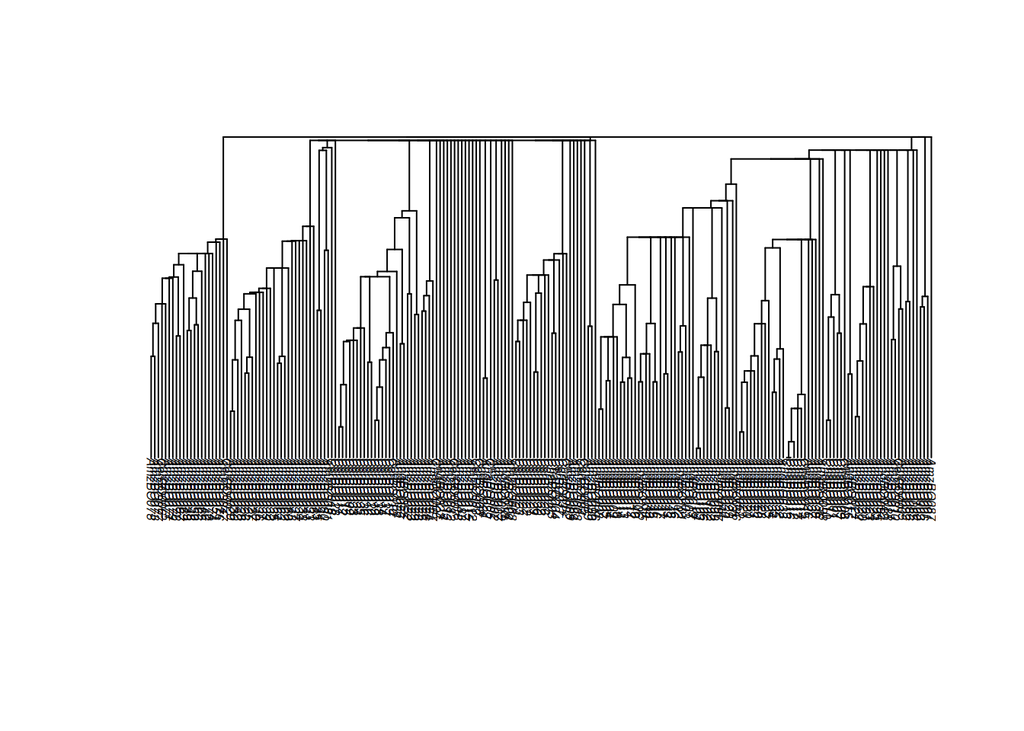

```r
bol_singlelink <- recluster.cons(spp_commat_trim, tr = 1, p = 0.5, dist = 'simpson', method = 'single')
bol_singlelink_tmp <- bol_singlelink$cons   # Selecting the consensus tree (we'll discuss it later)
plot(bol_singlelink_tmp, direction = 'downwards', cex = 0.5)
```

```r
# The write.tree function will let you save your cluster in TRE format so you can open it with Figtree and visualise it better.
write.tree(bol_singlelink_tmp, '01_bol_singlelink_temp.tre')
```

Let’s open this file in Figtree and see how we can use this software to our advantage. You can quickly download Figtree for your operating system here and install it on your computer. Figtree was originally designed to look at phylogenies, but we can use it to visualise dendograms (the outputs of our data clustering are called dendograms). You simply click on the document you want to open and select Figtree to open it. You can select branches and colour them to your liking with the `Colour` button. You can also zoom in with the `Zoom` button, allowing you to read the names on the tips of your dendogram and visualize your groups.

As you can see in the dendogram, we do not have any clearly defined groups. This is to be expected when using the single-linkage method, which is good for examining gradients in the dataset. You can still see some small groups scattered across the dendogram that are mainly formed by Amazonic (starting with Amz) and Andean (starting with And) sites.

Now that we have made our first cluster (congratulations!), there is something else you need to know. We are clustering data from a big dataset by using a distance matrix that most likely has many observations that are equally similar to one another. This means that these sites/samples can be clustered together in different ways and each way would be equally correct. How can we deal with this problem?

The answer is simple: we will build a solution which reflects the groups we encountered across different clusters made with the same distance matrix and the same linkage method. In other words, the solution will be made through a consensus. We will establish a criterion of inclusion that will indicate the number of times a certain subgroup/branch was recovered in a pool of equally valid solutions (dendograms) to our clustering problem. This is determined through the p argument. p can be any number ranging from 0.5 to 1 (recovered in 50% of the dendograms to recovered in 100% of the dendograms). Smaller numbers will give you a better chance of recovering sub-groups in your consensus dendogram. Numbers close to 100% will diminish that chance. The number you assign to the p argument largely depends on your research questions and on how stable you want your groups to be. The size of our solutions pool (equally possible and valid dendograms) is determined by the tr argument, the standard number to use here is 100.

Now, let’s see if we can get a better solution when using different, equally valid, dendograms to come up with a solution to our clustering problem.

#### Single-linkage method (concensus dendogram)

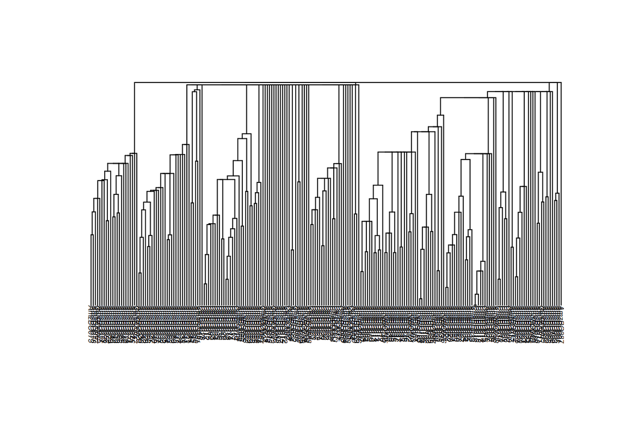

```r
bol_singlelink <- recluster.cons(spp_commat_trim, tr = 100, p = 0.5, method = 'single')
bol_singlelink_cons <- bol_singlelink$cons
write.tree(bol_singlelink_cons, '02_bol_singlelink_cons.tre')
plot(bol_singlelink_cons, direction = 'downwards', cex = 0.5)
```

Apart from a few sites changing their positions, the dendogram doesn’t look that different. This is largely because we have a lot of individual sites being treated as single groups. The order in which these sites are presented is not important, because the relationship between them is the same (they come up from the same node). There aren’t many differences in the solution because there is nothing much to vary in here, most groups are coming out of the same node.

Now we will move on to the other methods and we will always work with the solution reached through the application of the consensus criterion (p=0.5).

#### Complete-linkage method

Using the complete-linkage method, an observation is only allowed to be linked to a subgroup when it is more related to it than to the most distant pair of observations in that group. By doing so, when a observation is linked to a subgroup, you can assume that it is related to all observations in that group.

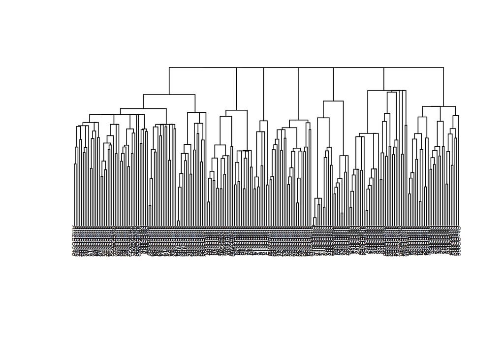

```r
bol_completelink <- recluster.cons(spp_commat_trim, tr = 100, p = 0.5, method = 'complete')
bol_completelink_cons <- bol_completelink$cons
write.tree(bol_completelink_cons, '03_bol_completelink_cons.tre')
plot(bol_completelink_cons, direction = 'downwards', cex = 0.5)
```

This is a great example of how important selecting a linkage method is! Look how well defined the groups are now, even though there are no clear relationships between the subgroups we’ve got (they all come out of the same node). Since the linkage criterion is more strict, the groups are better defined. You can open the file you’ve just created in Figtree and explore the subgroups.

The complete linkage method allows you to highlight discontinuities in your dataset, i.e. find out about potential gaps in your data. However, be advised that it is important for these groups to be ecologically meaningful and that is up to you to decide what that means. In here, you were given the phytogeographic domain in which these sites are located and how each site was classified according to its vegetation structure and other characteristics. You can use that in order to verify if these groups make sense from an ecological perspective.

#### Clustering using Ward’s minimum variance

This is a special kind of linkage method designed to form groups in a way that minimises the within group sum of squares (within total sum of squares expresses the amount of vegetation in each subgroup). This method is usually advisable when the groups obtained through data clustering will be used as categorical variables in subsequent analyses, such as ANOVAs and MANOVAs.

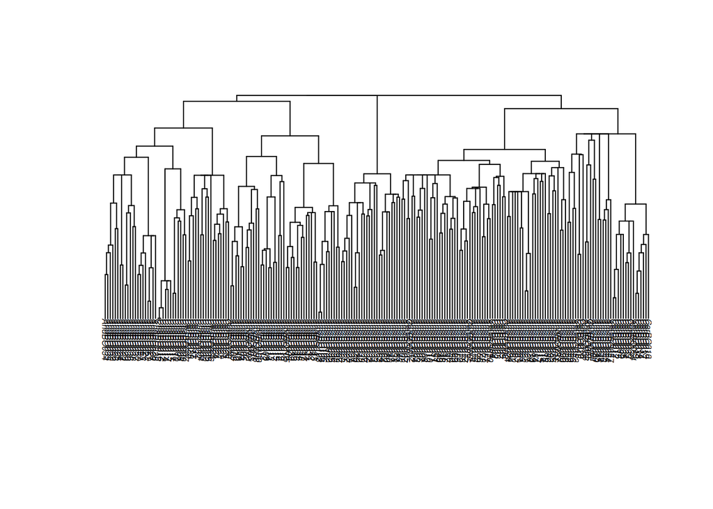

```r
bol_ward <- recluster.cons(spp_commat_trim, tr = 100, p = 0.5, method = 'ward.D')
bol_ward_cons <- bol_ward$cons
plot(bol_ward_cons, direction = 'downwards', cex = 0.5)
```

```r
write.tree(bol_ward_cons, '04_bol_ward_cons.tre')
```

This dendogram’s topology (‘dendogram topology’ refers the branching pattern relationship among individuals) is different from the other two dendograms we produced before. How many main groups can you see in here? Considering the phytogeographic domains in which these sites are located, are these groups ecologically meaningful? Why don’t you open the cluster you created with the complete linkage method and compare it with this one? How different are they? Which one would you use in order to perform further analysis?

#### Average linkage mehtod (UPGMA) and an observation on “uniques” and potential biases in the dendograms

Remember that I said we would investigate if there are any differences between the results you obtain with the complete presence/absence matrix and the matrix without any “uniques”? We are going to do it now. Will removing “uniques” improve the resolution within your dendograms or not? We’ll discover as soon as we learn more about the Average linkage method.

UPGMA stands for unweigthed Pair-Group Method Using Arithmetic Averages. Big name, I know. However, the name pretty much says how this linkage-method will link our observations: it will link our sites/samples by considering their distance to a subgroup’s arithmetic average (calculated using the pairwise distances). This is a very sensible linkage-method that usually tends to form ecologically meaningful groups and it is one of the most used hierarchical linkage methods in ecology, especially in biogeography. This is why the rest of our analyses will focus on this particular linkage method.

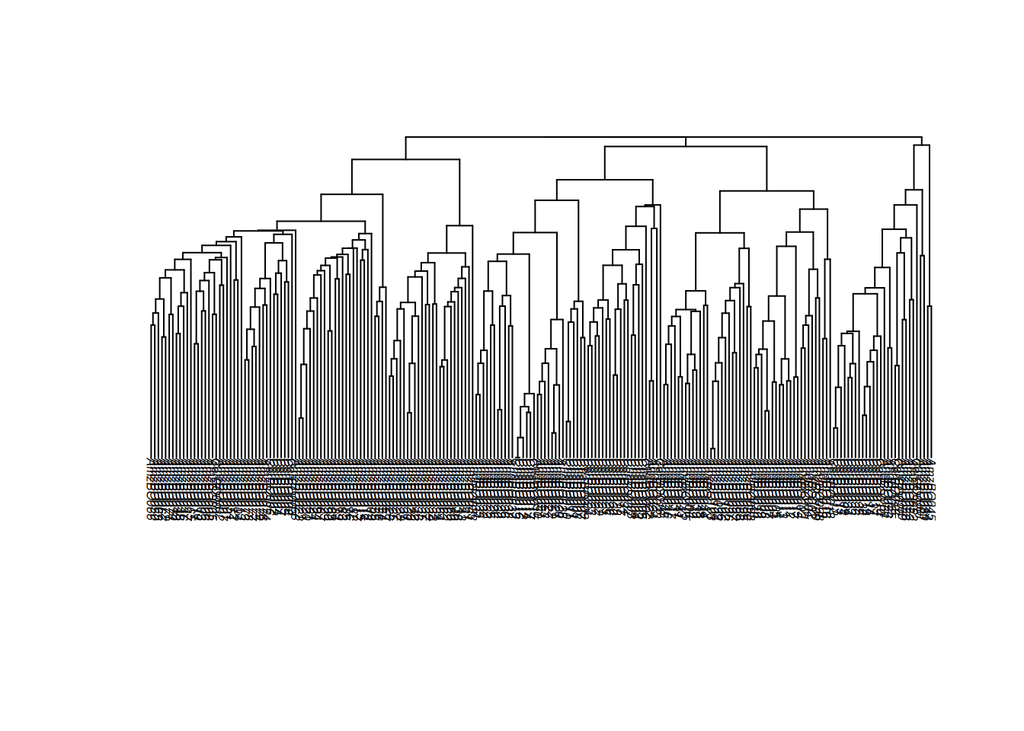

```r
# Full species presence/abscence matrix
bol_upgma <- recluster.cons(spp_commat, tr = 100, p = 0.5, method = 'average')
bol_upgma_cons <- bol_upgma$cons
write.tree(bol_upgma_cons, '05_bol_upgma_cons.tre')
plot(bol_upgma_cons, direction = 'downwards', cex = 0.5)
```

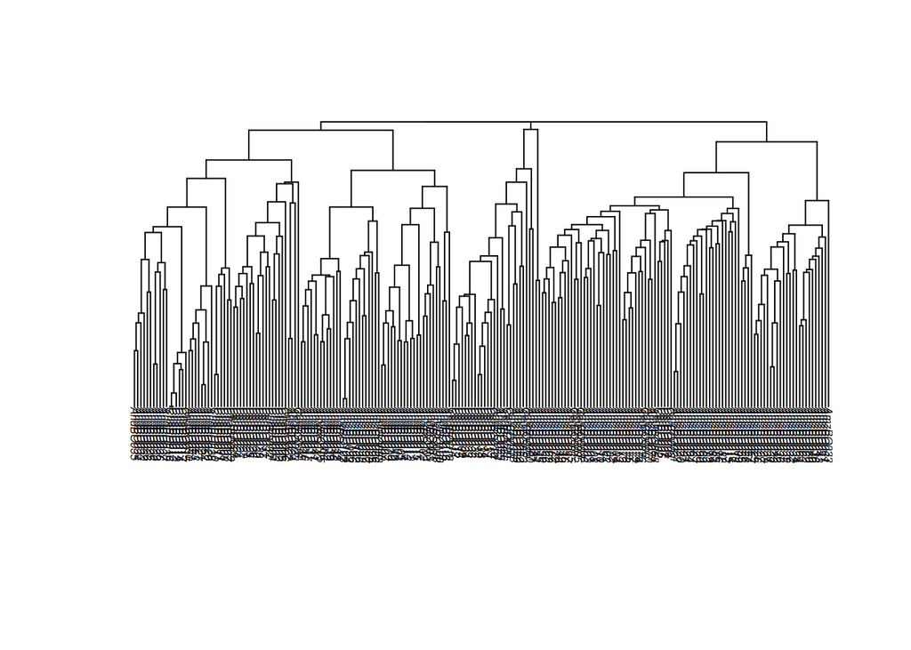

```r
# Trimmed species presence/absence matrix
bol_upgma_trim <- recluster.cons(spp_commat_trim, tr = 100, p = 0.5, method = 'average')
bol_upgma_trim_cons <- bol_upgma_trim$cons
write.tree(bol_upgma_trim_cons, '06_bol_upgma_cons_trim.tre')
plot(bol_upgma_trim_cons, direction = 'downwards', cex = 0.5)
```

So, at this point the author of the tutorial claims that the dendogram didn’t change. What actually happened is that the same dendogram was plotted twice. Doing it correctly does indeed reveal a change.

## 3. Bootstrap and support values for subgroups

Bootstrapping is one of the main ways of calculating support values for the subgroups we have got in our dendogram. It is usually used to test significance through randomisation procedures. However, since hierarchical clustering analysis do not work with significance, here bootstrapping assesses whether you’ll get the same subgroups in a dendogram even if you resample the species occurring in each site (with replacement - meaning you can repeat species and even not include some species at all. Bootstrap values range from 0 to 100 and express the proportion of times a certain subgroup was recovered during the resampling. The bigger the number, the stronger the subgroup.

However, bootstrap values tend to decrease when you have matrices with an unequal data distribution (a lot of zeroes). In our case, we have many sites and groups with low species richness. During the resampling, the calculation will end up removing species that are important to define groups, bringing the support values down, since the same groups will not be recovered. So don’t get frustrated by the low values we get, as bootstrapping is not useful in our case. Nevertheless, bootstrap values tend to be reliable when you have equally distributed data.

The boot argument tells the function how many randomizations you want to make before calculating the bootstrap values. The bigger the number, the longer it will take for your computer to run it. The standard number is 1000, but that takes at least three hours till you to get results. So we are going to set it to 10 instead.

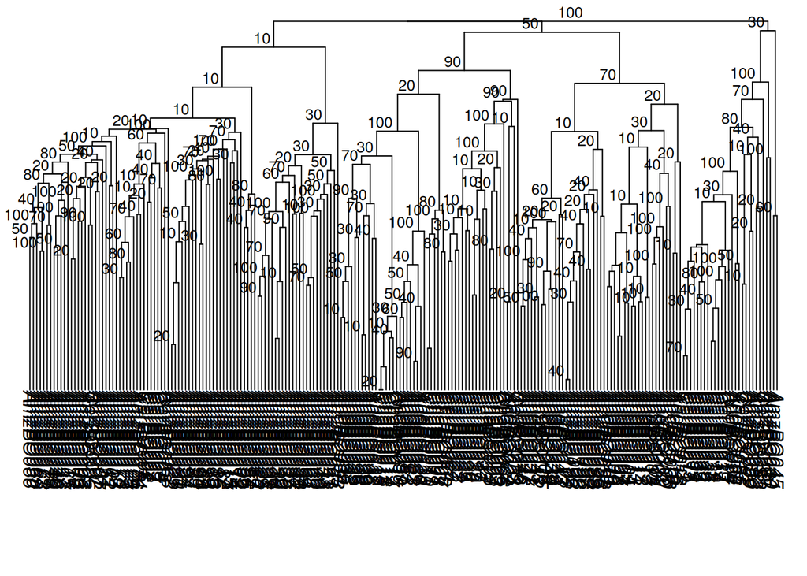

```r
bol_upgma_trim_boot <- recluster.boot(bol_upgma_trim_cons, spp_commat_trim, tr = 100, p = 0.5, method = "average", boot = 10, level = 1)
recluster.plot(bol_upgma_cons, bol_upgma_trim_boot, direction = "downwards")
```

There are some high values for a few of the groups in here, but if you set the boot value to a higher number (100 - 1000), the support values you found will go down.

## 4. Creating a grouoing variable